# Project Introduction

- Keywords

Data Exploration Analysis, Random Forest, XGBoost, Logistic Regression

# 1. Exploring Data

```python
import numpy as np               # linear algebra
import pandas as pd              # data processing, CSV file I/O (e.g. pd.read_csv)
import matplotlib.pyplot as plt
import seaborn as sns
import warnings
warnings.filterwarnings('ignore')
%matplotlib inline
```

```python
df=pd.read_csv('./2022_hotel_bookings.csv')
df.head()
```

|  | hotel | is_canceled | lead_time | arrival_date_year | arrival_date_month | arrival_date_week_number | arrival_date_day_of_month | stays_in_weekend_nights | stays_in_week_nights | adults | ... | deposit_type | agent | company | days_in_waiting_list | customer_type | adr | required_car_parking_spaces | total_of_special_requests | reservation_status | reservation_status_date |
| --- | --- | --- | --- | --- | --- | --- | --- | --- | --- | --- | --- | --- | --- | --- | --- | --- | --- | --- | --- | --- | --- |
| 0 | Resort Hotel | 0 | 342 | 2015 | July | 27 | 1 | 0 | 0 | 2 | ... | No Deposit | NaN | NaN | 0 | Transient | 0.0 | 0 | 0 | Check-Out | 2015-07-01 |
| 1 | Resort Hotel | 0 | 737 | 2015 | July | 27 | 1 | 0 | 0 | 2 | ... | No Deposit | NaN | NaN | 0 | Transient | 0.0 | 0 | 0 | Check-Out | 2015-07-01 |
| 2 | Resort Hotel | 0 | 7 | 2015 | July | 27 | 1 | 0 | 1 | 1 | ... | No Deposit | NaN | NaN | 0 | Transient | 75.0 | 0 | 0 | Check-Out | 2015-07-02 |
| 3 | Resort Hotel | 0 | 13 | 2015 | July | 27 | 1 | 0 | 1 | 1 | ... | No Deposit | 304.0 | NaN | 0 | Transient | 75.0 | 0 | 0 | Check-Out | 2015-07-02 |
| 4 | Resort Hotel | 0 | 14 | 2015 | July | 27 | 1 | 0 | 2 | 2 | ... | No Deposit | 240.0 | NaN | 0 | Transient | 98.0 | 0 | 1 | Check-Out | 2015-07-03 |

5 rows × 32 columns

```python
df.isnull().mean()
```

```
hotel                             0.000000
is_canceled                       0.000000
lead_time                         0.000000
arrival_date_year                 0.000000
arrival_date_month                0.000000
arrival_date_week_number          0.000000
arrival_date_day_of_month         0.000000
stays_in_weekend_nights           0.000000
stays_in_week_nights              0.000000
adults                            0.000000
children                          0.000034
babies                            0.000000
meal                              0.000000
country                           0.004087
market_segment                    0.000000
distribution_channel              0.000000
is_repeated_guest                 0.000000
previous_cancellations            0.000000
previous_bookings_not_canceled    0.000000
reserved_room_type                0.000000
assigned_room_type                0.000000
booking_changes                   0.000000
deposit_type                      0.000000
agent                             0.136862
company                           0.943069
days_in_waiting_list              0.000000
customer_type                     0.000000
adr                               0.000000
required_car_parking_spaces       0.000000
total_of_special_requests         0.000000
reservation_status                0.000000
reservation_status_date           0.000000
dtype: float64
```

```python
df.info()
```

```
<class 'pandas.core.frame.DataFrame'>
RangeIndex: 119390 entries, 0 to 119389
Data columns (total 32 columns):
 #   Column                          Non-Null Count   Dtype
---  ------                          --------------   -----
 0   hotel                           119390 non-null  object
 1   is_canceled                     119390 non-null  int64
 2   lead_time                       119390 non-null  int64
 3   arrival_date_year               119390 non-null  int64
 4   arrival_date_month              119390 non-null  object
 5   arrival_date_week_number        119390 non-null  int64
 6   arrival_date_day_of_month       119390 non-null  int64
 7   stays_in_weekend_nights         119390 non-null  int64
 8   stays_in_week_nights            119390 non-null  int64
 9   adults                          119390 non-null  int64
```

[output cut: 24 more lines]

```python
df.describe([0.01,0.05,0.1,0.25,0.5,0.75,0.99]).T
```

|  | count | mean | std | min | 1% | 5% | 10% | 25% | 50% | 75% | 99% | max |
| --- | --- | --- | --- | --- | --- | --- | --- | --- | --- | --- | --- | --- |
| is_canceled | 119390.0 | 0.370416 | 0.482918 | 0.00 | 0.0 | 0.0 | 0.0 | 0.00 | 0.000 | 1.0 | 1.00 | 1.0 |
| lead_time | 119390.0 | 104.011416 | 106.863097 | 0.00 | 0.0 | 0.0 | 3.0 | 18.00 | 69.000 | 160.0 | 444.00 | 737.0 |
| arrival_date_year | 119390.0 | 2016.156554 | 0.707476 | 2015.00 | 2015.0 | 2015.0 | 2015.0 | 2016.00 | 2016.000 | 2017.0 | 2017.00 | 2017.0 |
| arrival_date_week_number | 119390.0 | 27.165173 | 13.605138 | 1.00 | 2.0 | 5.0 | 8.0 | 16.00 | 28.000 | 38.0 | 53.00 | 53.0 |
| arrival_date_day_of_month | 119390.0 | 15.798241 | 8.780829 | 1.00 | 1.0 | 2.0 | 4.0 | 8.00 | 16.000 | 23.0 | 31.00 | 31.0 |
| stays_in_weekend_nights | 119390.0 | 0.927599 | 0.998613 | 0.00 | 0.0 | 0.0 | 0.0 | 0.00 | 1.000 | 2.0 | 4.00 | 19.0 |
| stays_in_week_nights | 119390.0 | 2.500302 | 1.908286 | 0.00 | 0.0 | 0.0 | 1.0 | 1.00 | 2.000 | 3.0 | 10.00 | 50.0 |
| adults | 119390.0 | 1.856403 | 0.579261 | 0.00 | 1.0 | 1.0 | 1.0 | 2.00 | 2.000 | 2.0 | 3.00 | 55.0 |
| children | 119386.0 | 0.103890 | 0.398561 | 0.00 | 0.0 | 0.0 | 0.0 | 0.00 | 0.000 | 0.0 | 2.00 | 10.0 |
| babies | 119390.0 | 0.007949 | 0.097436 | 0.00 | 0.0 | 0.0 | 0.0 | 0.00 | 0.000 | 0.0 | 0.00 | 10.0 |
| is_repeated_guest | 119390.0 | 0.031912 | 0.175767 | 0.00 | 0.0 | 0.0 | 0.0 | 0.00 | 0.000 | 0.0 | 1.00 | 1.0 |
| previous_cancellations | 119390.0 | 0.087118 | 0.844336 | 0.00 | 0.0 | 0.0 | 0.0 | 0.00 | 0.000 | 0.0 | 1.00 | 26.0 |
| previous_bookings_not_canceled | 119390.0 | 0.137097 | 1.497437 | 0.00 | 0.0 | 0.0 | 0.0 | 0.00 | 0.000 | 0.0 | 3.00 | 72.0 |
| booking_changes | 119390.0 | 0.221124 | 0.652306 | 0.00 | 0.0 | 0.0 | 0.0 | 0.00 | 0.000 | 0.0 | 3.00 | 21.0 |
| agent | 103050.0 | 86.693382 | 110.774548 | 1.00 | 1.0 | 1.0 | 6.0 | 9.00 | 14.000 | 229.0 | 390.00 | 535.0 |
| company | 6797.0 | 189.266735 | 131.655015 | 6.00 | 16.0 | 40.0 | 40.0 | 62.00 | 179.000 | 270.0 | 513.04 | 543.0 |
| days_in_waiting_list | 119390.0 | 2.321149 | 17.594721 | 0.00 | 0.0 | 0.0 | 0.0 | 0.00 | 0.000 | 0.0 | 75.00 | 391.0 |
| adr | 119390.0 | 101.831122 | 50.535790 | -6.38 | 0.0 | 38.4 | 50.0 | 69.29 | 94.575 | 126.0 | 252.00 | 5400.0 |
| required_car_parking_spaces | 119390.0 | 0.062518 | 0.245291 | 0.00 | 0.0 | 0.0 | 0.0 | 0.00 | 0.000 | 0.0 | 1.00 | 8.0 |
| total_of_special_requests | 119390.0 | 0.571363 | 0.792798 | 0.00 | 0.0 | 0.0 | 0.0 | 0.00 | 0.000 | 1.0 | 3.00 | 5.0 |

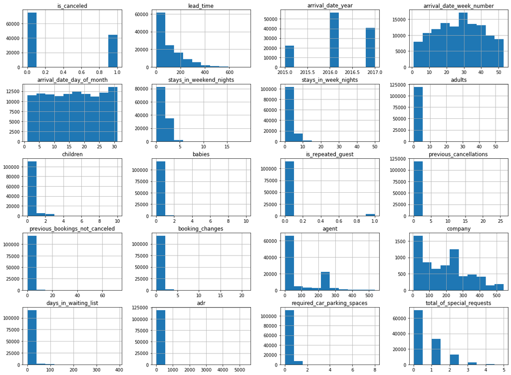

```python
df.hist(figsize=(20,15))
plt.show()
```

# 3 Data Visualization Analysis

## 3.1 Hotel Booking and Cancellation

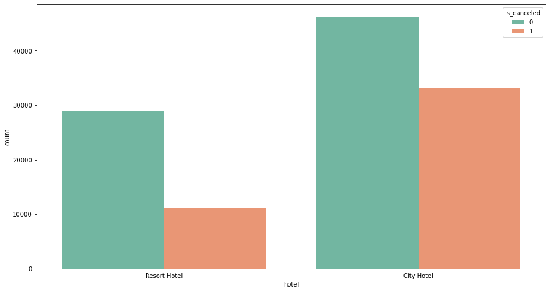

```python
plt.figure(figsize=(15,8))
sns.countplot(x='hotel'
             ,data=df
             ,hue='is_canceled'
             ,palette=sns.color_palette('Set2',2)
            )
```

```python
hotel_cancel=(df.loc[df['is_canceled']==1]['hotel'].value_counts()/df['hotel'].value_counts()).sort_values(ascending=False)
print('Hotel Cancel Rate'.center(20),hotel_cancel,sep='\n')
```

```
 Hotel Cancel Rate
City Hotel      0.417270
Resort Hotel    0.277634
Name: hotel, dtype: float64
```

City Hotel has higher bookings and cancellations than Resort Hotel, but Resort Hotel has a cancellation rate of 27.8%, while City Hotel has a cancellation rate of 41.7%.

## 3.2 Monthly Hotel Bookings

```python
city_hotel=df[(df['hotel']=='City Hotel') & (df['is_canceled']==0)]
resort_hotel=df[(df['hotel']=='Resort Hotel') & (df['is_canceled']==0)]
for i in [city_hotel,resort_hotel]:
    i.index=range(i.shape[0])
```

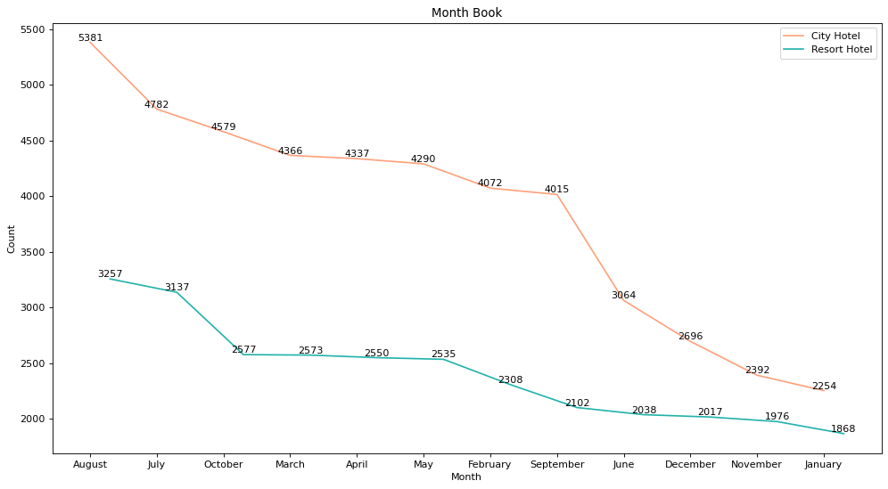

```python
city_month=city_hotel['arrival_date_month'].value_counts()
resort_month=resort_hotel['arrival_date_month'].value_counts()
name=resort_month.index
x=list(range(len(city_month.index)))
y=city_month.values
x1=[i+0.3 for i in x]
y1=resort_month.values
width=0.3
plt.figure(figsize=(15,8),dpi=80)
plt.plot(x,y,label='City Hotel',color='lightsalmon')
plt.plot(x1,y1,label='Resort Hotel',color='lightseagreen')
plt.xticks(x,name)
plt.legend()
plt.xlabel('Month')
plt.ylabel('Count')
plt.title('Month Book')
for x,y in zip(x,y):
    plt.text(x,y+0.1,'%d' % y,ha = 'center',va = 'bottom')

for x,y in zip(x1,y1):
    plt.text(x,y+0.1,'%d' % y,ha = 'center',va = 'bottom')
```

## 3.3 Origin of Customers and Cancellation Rate

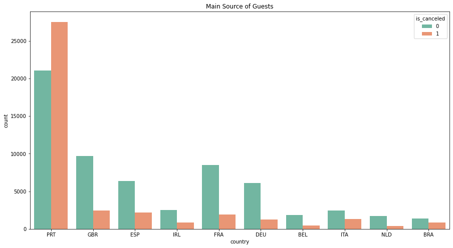

```python
country_book=df['country'].value_counts()[:10]
country_cancel=df[(df.country.isin (country_book.index)) & (df.is_canceled==1)]['country'].value_counts()
plt.figure(figsize=(15,8))
sns.countplot(x='country'
              ,data=df[df.country.isin (country_book.index)]
              ,hue='is_canceled'
              ,palette=sns.color_palette('Set2',2)
             )
plt.title('Main Source of Guests')
```

```python
country_cancel_rate=(country_cancel/country_book).sort_values(ascending=False)
print('Customer Cancel Rate by Nations'.center(10),country_cancel_rate,sep='\n')
```

```
Customer Cancel Rate by Nations
PRT    0.566351
BRA    0.373201
ITA    0.353956
ESP    0.254085
IRL    0.246519
BEL    0.202391
GBR    0.202243
FRA    0.185694
NLD    0.183935
DEU    0.167147
Name: country, dtype: float64
```

## 3.4 Customer Types

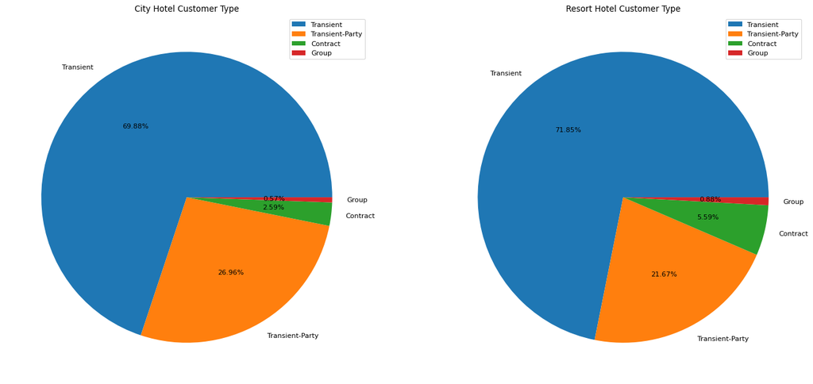

```python
city_customer=city_hotel.customer_type.value_counts()
resort_customer=resort_hotel.customer_type.value_counts()
plt.figure(figsize=(21,12),dpi=80)
plt.subplot(1,2,1)
plt.pie(city_customer,labels=city_customer.index,autopct='%.2f%%')
plt.legend(loc=1)
plt.title('City Hotel Customer Type')
plt.subplot(1,2,2)
plt.pie(resort_customer,labels=resort_customer.index,autopct='%.2f%%')
plt.title('Resort Hotel Customer Type')
plt.legend()
plt.show()
```

The main customer type of the hotel is transient, accounting for about 70%

## 3.5 Hotel Booking Channels

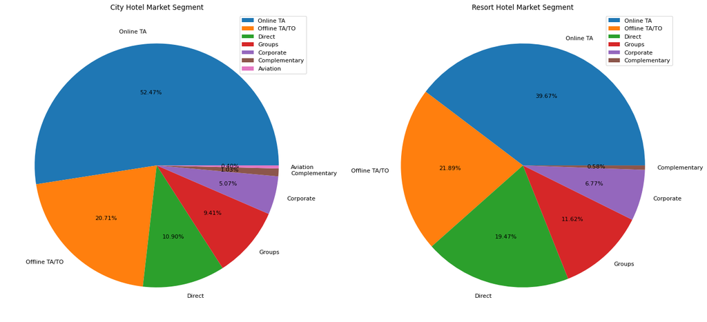

```python
city_segment=city_hotel.market_segment.value_counts()
resort_segment=resort_hotel.market_segment.value_counts()
plt.figure(figsize=(21,12),dpi=80)
plt.subplot(1,2,1)
plt.pie(city_segment,labels=city_segment.index,autopct='%.2f%%')
plt.legend()
plt.title('City Hotel Market Segment')
plt.subplot(1,2,2)
plt.pie(resort_segment,labels=resort_segment.index,autopct='%.2f%%')
plt.title('Resort Hotel Market Segment')
plt.legend()
plt.show()
```

The customers of the two hotels mainly come from online travel agencies, which account for more than 50% of City Hotel’s customers. Offline travel agencies account for the second largest proportion, both accounting for about 20%.

## 3.6 Daily Expenditure of Different Types of Guests

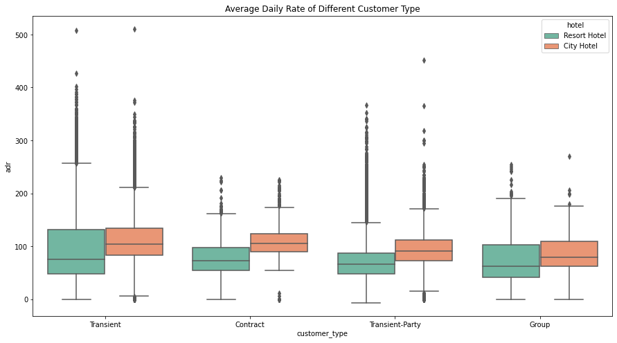

```python
plt.figure(figsize=(15,8))
sns.boxplot(x='customer_type'
            ,y='adr'
            ,hue='hotel'
            ,data=df[df.is_canceled==0]
            ,palette=sns.color_palette('Set2',2)
           )
plt.title('Average Daily Rate of Different Customer Type')
```

The average daily spending of all types of customers at City Hotel is higher than that of Resort Hotel. Among the four types of customers, Transient customers spend the most, while Group customers spend the least.

## 3.7 New and Returning Guests and Cancellation Rate

[output not shown]

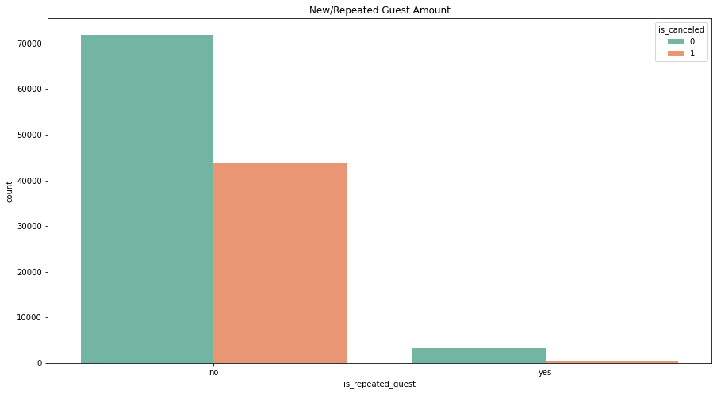

```python
plt.figure(figsize=(15,8))
sns.countplot(x='is_repeated_guest'
              ,data=df
              ,hue='is_canceled'
              ,palette=sns.color_palette('Set2',2)
             )
plt.title('New/Repeated Guest Amount')
plt.xticks(range(2),['no','yes'])
```

```python
guest_cancel=(df.loc[df['is_canceled']==1]['is_repeated_guest'].value_counts()/df['is_repeated_guest'].value_counts()).sort_values(ascending=False)
guest_cancel.index=['New Guest', 'Repeated Guest']
print('New and Old Customer Cancel Rate'.center(15),guest_cancel,sep='\n')
```

```
New and Old Customer Cancel Rate
New Guest         0.377851
Repeated Guest    0.144882
Name: is_repeated_guest, dtype: float64
```

The cancellation rate of old customers is 14.4%, while the cancellation rate of new customers is 37.8%, 24 percentage points higher than that of old customers.

## 3.8 Deposit Methods and Cancellation Rate

```python
print('Three deposit methods for reservation'.center(15),df['deposit_type'].value_counts(),sep='\n')
```

```
Three deposit methods for reservation
No Deposit    104641
Non Refund     14587
Refundable       162
Name: deposit_type, dtype: int64
```

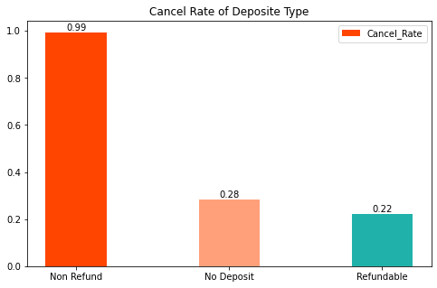

```python
deposit_cancel=(df.loc[df['is_canceled']==1]['deposit_type'].value_counts()/df['deposit_type'].value_counts()).sort_values(ascending=False)
plt.figure(figsize=(8,5))
x=range(len(deposit_cancel.index))
y=deposit_cancel.values
plt.bar(x,y,label='Cancel_Rate',color=['orangered','lightsalmon','lightseagreen'],width=0.4)
plt.xticks(x,deposit_cancel.index)
plt.legend()
plt.title('Cancel Rate of Deposite Type')
for x,y in zip(x,y):
    plt.text(x,y,'%.2f' % y,ha = 'center',va = 'bottom')
```

No deposit is the most popular booking method with a low cancellation rate, while the cancellation rate of non-refundable bookings is as high as 99%. You can reduce this type of deposit to reduce customer cancellation rates.

## 3.9 Room Types and Cancellation Rate

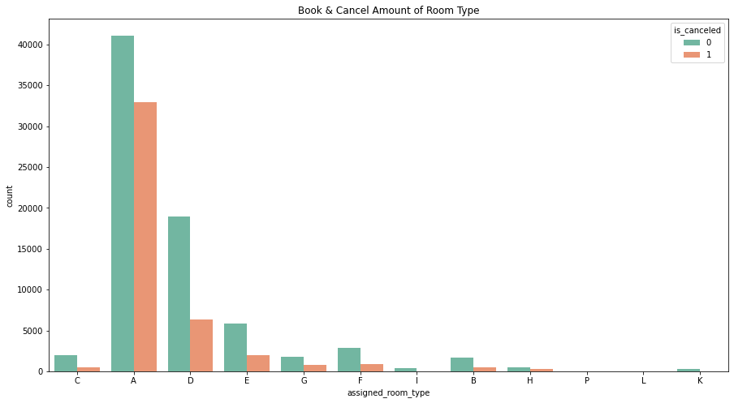

```python
plt.figure(figsize=(15,8))
sns.countplot(x='assigned_room_type'
              ,data=df
              ,hue='is_canceled'
              ,palette=sns.color_palette('Set2',2)
             )
plt.title('Book & Cancel Amount of Room Type')
```

```python
room_cancel=df.loc[df['is_canceled']==1]['assigned_room_type'].value_counts()[:7]/df['assigned_room_type'].value_counts()[:7]
print('Cancellation rate by room type'.center(5),room_cancel.sort_values(ascending=False),sep='\n')
```

```
Cancellation rate by room type
A    0.444925
G    0.305523
E    0.252114
D    0.251244
F    0.247134
B    0.236708
C    0.187789
Name: assigned_room_type, dtype: float64
```

Among the top 7 room types in terms of booking volume, the cancellation rates of room types A and G are higher than those of other room types, and the cancellation rate of room type A is as high as 44.5%.

## 3.10 Analysis Summary

- 1. The booking volume and cancellation rate of City Hotel are much higher than those of Resort Hotel. The hotel should conduct customer surveys to gain a deeper understanding of the factors that lead customers to give up bookings, thereby reducing the customer cancellation rate.
- 2. The hotel should make good use of the peak tourist season in July and August each year. It can increase prices appropriately to obtain more profits while ensuring service quality. It can also conduct preferential activities in the off-season (winter), such as Christmas promotions and New Year activities, to reduce hotel vacancy rates.
- 3. The hotel needs to analyze the customer portraits from major source countries such as Portugal and the United Kingdom, understand the attribute labels, preferences and consumption characteristics of these customers, and launch exclusive services to reduce the customer cancellation rate.
- 4. Since individual travelers are the main customer group of the hotel and have a high consumption level, the hotel can increase the publicity and marketing of free travel through online and offline travel agencies to attract more tourists of this type.
- 5. The cancellation rate of new guests is 24% higher than that of old guests. Therefore, hotels should focus on the booking and check-in experience of new guests, provide more guidance and discounts for new guests, such as providing discounts for first-time guests, and survey new guests' feedback on satisfaction and dissatisfaction with their stay to improve future services, while maintaining good service for old guests.
- 6. The cancellation rate of non-refundable deposits is as high as 99%. Hotels should optimize this method, such as returning 50% of the deposit, or directly canceling this method, so as to increase the occupancy rate.
- 7. The cancellation rate of A and G room types is much higher than that of other room types. Hotels should carefully confirm room information with customers when booking, so that customers have a full understanding of the room situation and avoid cognitive errors. At the same time, they can optimize room facilities and improve service levels.

# 4 Data Preprocessing

```python
df1=df.drop(labels=['reservation_status_date'],axis=1)
```

## 4.1 Processing Categorical Variables

```python
cate=df1.columns[df1.dtypes == "object"].tolist()

num_cate=['agent','company','is_repeated_guest']
cate=cate+num_cate
```

```python
results={}
for i in ['agent','company']:
    result=np.sort(df1[i].unique())
    results[i]=result
results
```

```
{'agent': array([  1.,   2.,   3.,   4.,   5.,   6.,   7.,   8.,   9.,  10.,  11.,
         12.,  13.,  14.,  15.,  16.,  17.,  19.,  20.,  21.,  22.,  23.,
         24.,  25.,  26.,  27.,  28.,  29.,  30.,  31.,  32.,  33.,  34.,
         35.,  36.,  37.,  38.,  39.,  40.,  41.,  42.,  44.,  45.,  47.,
         50.,  52.,  53.,  54.,  55.,  56.,  57.,  58.,  59.,  60.,  61.,
         63.,  64.,  66.,  67.,  68.,  69.,  70.,  71.,  72.,  73.,  74.,
         75.,  77.,  78.,  79.,  81.,  82.,  83.,  85.,  86.,  87.,  88.,
         89.,  90.,  91.,  92.,  93.,  94.,  95.,  96.,  98.,  99., 103.,
        104., 105., 106., 107., 110., 111., 112., 114., 115., 117., 118.,
        119., 121., 122., 126., 127., 128., 129., 132., 133., 134., 135.,
        138., 139., 141., 142., 143., 144., 146., 147., 148., 149., 150.,
        151., 152., 153., 154., 155., 156., 157., 158., 159., 162., 163.,
        165., 167., 168., 170., 171., 173., 174., 175., 177., 179., 180.,
        181., 182., 183., 184., 185., 187., 191., 192., 193., 195., 196.,
        197., 201., 205., 208., 210., 211., 213., 214., 215., 216., 219.,
        220., 223., 227., 229., 232., 234., 235., 236., 240., 241., 242.,
        243., 244., 245., 247., 248., 249., 250., 251., 252., 253., 254.,
        256., 257., 258., 261., 262., 265., 267., 269., 270., 273., 275.,
        276., 278., 280., 281., 282., 283., 285., 286., 287., 288., 289.,
        290., 291., 294., 295., 296., 298., 299., 300., 301., 302., 303.,
        304., 305., 306., 307., 308., 310., 313., 314., 315., 321., 323.,
        324., 325., 326., 327., 328., 330., 331., 332., 333., 334., 335.,
        336., 337., 339., 341., 344., 346., 348., 350., 352., 354., 355.,
        358., 359., 360., 363., 364., 367., 368., 370., 371., 375., 378.,
        384., 385., 387., 388., 390., 391., 393., 394., 397., 403., 404.,
        405., 406., 408., 410., 411., 414., 416., 418., 420., 423., 425.,
        426., 427., 429., 430., 431., 432., 433., 434., 436., 438., 440.,
        441., 444., 446., 449., 450., 451., 453., 454., 455., 459., 461.,
        464., 467., 468., 469., 472., 474., 475., 476., 479., 480., 481.,
        483., 484., 492., 493., 495., 497., 502., 508., 509., 510., 526.,
        527., 531., 535.,  nan]),
 'company': array([  6.,   8.,   9.,  10.,  11.,  12.,  14.,  16.,  18.,  20.,  22.,
         28.,  29.,  31.,  32.,  34.,  35.,  37.,  38.,  39.,  40.,  42.,
         43.,  45.,  46.,  47.,  48.,  49.,  51.,  52.,  53.,  54.,  59.,
         61.,  62.,  64.,  65.,  67.,  68.,  71.,  72.,  73.,  76.,  77.,
         78.,  80.,  81.,  82.,  83.,  84.,  85.,  86.,  88.,  91.,  92.,
         93.,  94.,  96.,  99., 100., 101., 102., 103., 104., 105., 106.,
        107., 108., 109., 110., 112., 113., 115., 116., 118., 120., 122.,
        126., 127., 130., 132., 135., 137., 139., 140., 142., 143., 144.,
        146., 148., 149., 150., 153., 154., 158., 159., 160., 163., 165.,
```

[output cut: 9 more lines]

```
        321., 323., 324., 325., 329., 330., 331., 332., 333., 334., 337.,
        338., 341., 342., 343., 346., 347., 348., 349., 350., 351., 352.,
        353., 355., 356., 357., 358., 360., 361., 362., 364., 365., 366.,
        367., 368., 369., 370., 371., 372., 373., 376., 377., 378., 379.,
        380., 382., 383., 384., 385., 386., 388., 390., 391., 392., 393.,
        394., 395., 396., 397., 398., 399., 400., 401., 402., 403., 405.,
        407., 408., 409., 410., 411., 412., 413., 415., 416., 417., 418.,
        419., 420., 421., 422., 423., 424., 425., 426., 428., 429., 433.,
        435., 436., 437., 439., 442., 443., 444., 445., 446., 447., 448.,
        450., 451., 452., 454., 455., 456., 457., 458., 459., 460., 461.,
        465., 466., 470., 477., 478., 479., 481., 482., 483., 484., 485.,
        486., 487., 489., 490., 491., 492., 494., 496., 497., 498., 499.,
        501., 504., 506., 507., 511., 512., 513., 514., 515., 516., 518.,
        520., 521., 523., 525., 528., 530., 531., 534., 539., 541., 543.,
         nan])}
```

```python
df1[['agent','company']]=df1[['agent','company']].fillna(0,axis=0)
```

```python
df1.loc[:,cate].isnull().mean()
```

```
hotel                   0.000000
arrival_date_month      0.000000
meal                    0.000000
country                 0.004087
market_segment          0.000000
distribution_channel    0.000000
reserved_room_type      0.000000
assigned_room_type      0.000000
deposit_type            0.000000
customer_type           0.000000
reservation_status      0.000000
agent                   0.000000
company                 0.000000
is_repeated_guest       0.000000
dtype: float64
```

```python
df1.loc[df1['company'] == 0,'in_company']='NO'
df1.loc[df1['company'] != 0,'in_company']='YES'
df1.loc[df1['agent'] == 0,'in_agent']='NO'
df1.loc[df1['agent'] != 0,'in_agent']='YES'
```

```python
df1.loc[df1['reserved_room_type'] == df1['assigned_room_type'],'same_assignment']='Yes'
df1.loc[df1['reserved_room_type'] != df1['assigned_room_type'],'same_assignment']='No'
```

```python
df1=df1.drop(labels=['reserved_room_type','assigned_room_type','agent','company'],axis=1)
```

```python
df1['is_repeated_guest'][df1['is_repeated_guest']==0]='NO'
df1['is_repeated_guest'][df1['is_repeated_guest']==1]='YES'
```

```python
df1['country']=df1['country'].fillna(df1['country'].mode()[0])
```

```python
for i in ['in_company','in_agent','same_assignment']:
    cate.append(i)

for i in ['reserved_room_type','assigned_room_type','agent','company']:
    cate.remove(i)
cate
```

```
['hotel',
 'arrival_date_month',
 'meal',
 'country',
 'market_segment',
 'distribution_channel',
 'deposit_type',
 'customer_type',
 'reservation_status',
 'is_repeated_guest',
 'in_company',
 'in_agent',
 'same_assignment']
```

```python
!pip install scikit-learn -i https://pypi.mirrors.ustc.edu.cn/simple/
```

```python
from sklearn.preprocessing import OrdinalEncoder

oe = OrdinalEncoder()
oe = oe.fit(df1.loc[:,cate])
df1.loc[:,cate] = oe.transform(df1.loc[:,cate])
```

## 4.2 Processing Continuous Variables

```python
col=df1.columns.tolist()
col.remove('is_canceled')
for i in cate:
    col.remove(i)
col
```

```
['lead_time',
 'arrival_date_year',
 'arrival_date_week_number',
 'arrival_date_day_of_month',
 'stays_in_weekend_nights',
 'stays_in_week_nights',
 'adults',
 'children',
 'babies',
 'previous_cancellations',
 'previous_bookings_not_canceled',
 'booking_changes',
 'days_in_waiting_list',
 'adr',
 'required_car_parking_spaces',
 'total_of_special_requests']
```

```python
df1[col].isnull().sum()
```

```
lead_time                         0
arrival_date_year                 0
arrival_date_week_number          0
arrival_date_day_of_month         0
stays_in_weekend_nights           0
stays_in_week_nights              0
adults                            0
children                          4
babies                            0
previous_cancellations            0
previous_bookings_not_canceled    0
booking_changes                   0
days_in_waiting_list              0
adr                               0
required_car_parking_spaces       0
total_of_special_requests         0
dtype: int64
```

```python
df1['children']=df1['children'].fillna(df1['children'].mode()[0])
```

```python
from sklearn.preprocessing import StandardScaler
ss = StandardScaler()
ss = ss.fit(df1.loc[:,col])
df1.loc[:,col] = ss.transform(df1.loc[:,col])
```

## 4.3 Correlation Coefficients of Variables

```python
cor=df1.corr()
cor=abs(cor['is_canceled']).sort_values()
cor
```

```
arrival_date_month                0.001491
stays_in_weekend_nights           0.001791
children                          0.005036
arrival_date_day_of_month         0.006130
arrival_date_week_number          0.008148
arrival_date_year                 0.016660
meal                              0.017678
stays_in_week_nights              0.024765
babies                            0.032491
adr                               0.047557
days_in_waiting_list              0.054186
previous_bookings_not_canceled    0.057358
market_segment                    0.059338
adults                            0.060017
customer_type                     0.068140
is_repeated_guest                 0.084793
in_company                        0.099310
in_agent                          0.102068
previous_cancellations            0.110133
hotel                             0.136531
booking_changes                   0.144381
distribution_channel              0.167600
required_car_parking_spaces       0.195498
total_of_special_requests         0.234658
same_assignment                   0.247770
country                           0.267502
lead_time                         0.293123
deposit_type                      0.468634
reservation_status                0.917196
is_canceled                       1.000000
Name: is_canceled, dtype: float64
```

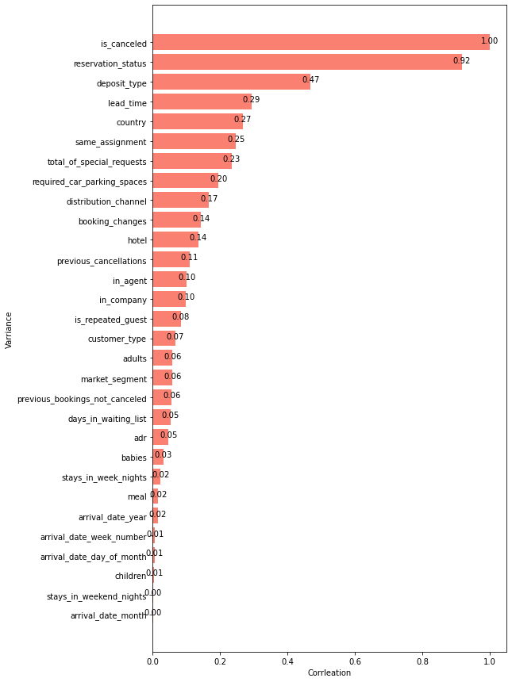

```python
plt.figure(figsize=(8,15))
x=range(len(cor.index))
name=cor.index
y=abs(cor.values)
plt.barh(x,y,color='salmon')
plt.yticks(x,name)
for x,y in zip(x,y):
    plt.text(y,x-0.1,'%.2f' % y,ha = 'center',va = 'bottom')
plt.xlabel('Corrleation')
plt.ylabel('Varriance')
plt.show()
```

The reservation status ('reservation_status') has the highest correlation with whether to cancel the reservation, reaching 0.92, but considering that it may cause overfitting of the model in the future, it is deleted; the deposit type ('deposit_type') reaches 0.47, and the created feature reservation and whether the assigned room type is consistent ('same_assignment') also have a correlation of 0.25

```python
df2=df1.drop('reservation_status',axis=1)
```

# 5 Modeling and Prediction

```python
# 划分特征x和标签y
x=df2.loc[:,df2.columns != 'is_canceled' ]
y=df2.loc[:,'is_canceled']
from sklearn.model_selection import train_test_split as tts
xtrain,xtest,ytrain,ytest=tts(x,y,test_size=0.3,random_state=90)
for i in [xtrain,xtest,ytrain,ytest]:
    i.index=range(i.shape[0])
```

## 5.1 Random Forest

```python
from sklearn.ensemble import RandomForestClassifier
from sklearn.model_selection import cross_val_score as cvs,KFold
from sklearn.metrics import accuracy_score
rfc=RandomForestClassifier(n_estimators=100,random_state=90)
cv=KFold(n_splits=10, shuffle = True, random_state=90)
rfc_score=cvs(rfc,xtrain,ytrain,cv=cv).mean()
rfc.fit(xtrain,ytrain)
y_score=rfc.predict_proba(xtest)[:,1]
rfc_pred=rfc.predict(xtest)
from sklearn.metrics import roc_curve
from sklearn.metrics import roc_auc_score as AUC
FPR, recall, thresholds = roc_curve(ytest,y_score, pos_label=1)
rfc_auc = AUC(ytest,y_score)
```

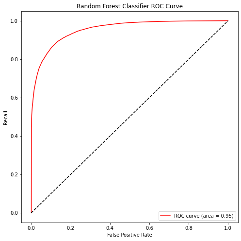

```python
plt.figure(figsize=(8,8))
plt.plot(FPR, recall, color='red',label='ROC curve (area = %0.2f)' % rfc_auc)
plt.plot([0, 1], [0, 1], color='black', linestyle='--')
plt.xlim([-0.05, 1.05])
plt.ylim([-0.05, 1.05])
plt.xlabel('False Positive Rate')
plt.ylabel('Recall')
plt.title('Random Forest Classifier ROC Curve')
plt.legend(loc="lower right")
plt.show()
```

## 5.2 XGBoost

```python
xtrain.info()
```

```
<class 'pandas.core.frame.DataFrame'>
RangeIndex: 83573 entries, 0 to 83572
Data columns (total 28 columns):
 #   Column                          Non-Null Count  Dtype
---  ------                          --------------  -----
 0   hotel                           83573 non-null  float64
 1   lead_time                       83573 non-null  float64
 2   arrival_date_year               83573 non-null  float64
 3   arrival_date_month              83573 non-null  float64
 4   arrival_date_week_number        83573 non-null  float64
 5   arrival_date_day_of_month       83573 non-null  float64
 6   stays_in_weekend_nights         83573 non-null  float64
 7   stays_in_week_nights            83573 non-null  float64
 8   adults                          83573 non-null  float64
 9   children                        83573 non-null  float64
```

[output cut: 20 more lines]

```python
from xgboost import XGBClassifier
xgbr=XGBClassifier(n_estimators=100,random_state=90)
xgbr_score=cvs(xgbr,xtrain,ytrain,cv=cv).mean()
xgbr.fit(xtrain,ytrain)
y_score=xgbr.predict_proba(xtest)[:,1]
xgbr_pred=xgbr.predict(xtest)
FPR, recall, thresholds = roc_curve(ytest,y_score, pos_label=1)
xgbr_auc = AUC(ytest,y_score)
```

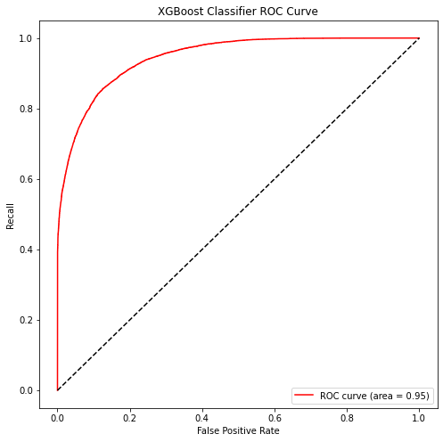

```python
plt.figure(figsize=(8,8))
plt.plot(FPR, recall, color='red',label='ROC curve (area = %0.2f)' % xgbr_auc)
plt.plot([0, 1], [0, 1], color='black', linestyle='--')
plt.xlim([-0.05, 1.05])
plt.ylim([-0.05, 1.05])
plt.xlabel('False Positive Rate')
plt.ylabel('Recall')
plt.title('XGBoost Classifier ROC Curve')
plt.legend(loc="lower right")
plt.show()
```

## 5.3 Logistic Regression

```python
from sklearn.linear_model import LogisticRegression as LR
lr = LR(penalty='l2',solver='liblinear',max_iter=1000)
lr_score=cvs(lr,xtrain,ytrain,cv=cv).mean()
lr.fit(xtrain,ytrain)
y_score=lr.predict_proba(xtest)[:,1]
lr_pred=lr.predict(xtest)
FPR, recall, thresholds = roc_curve(ytest,y_score, pos_label=1)
lr_auc = AUC(ytest,y_score)
```

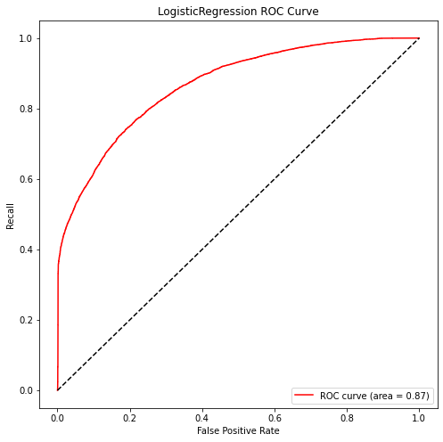

```python
plt.figure(figsize=(8,8))
plt.plot(FPR, recall, color='red',label='ROC curve (area = %0.2f)' % lr_auc)
plt.plot([0, 1], [0, 1], color='black', linestyle='--')
plt.xlim([-0.05, 1.05])
plt.ylim([-0.05, 1.05])
plt.xlabel('False Positive Rate')
plt.ylabel('Recall')
plt.title('LogisticRegression ROC Curve')
plt.legend(loc="lower right")
plt.show()
```

## 5.4 Summary

```python
from sklearn.metrics import classification_report as CR
print('随机森林'.center(50), CR(ytest,rfc_pred),sep='\n')
print('XGBoost'.center(55),CR(ytest,xgbr_pred),sep='\n')
print('逻辑回归'.center(50),CR(ytest,lr_pred),sep='\n')
```

```
                       随机森林
              precision    recall  f1-score   support

           0       0.89      0.93      0.91     22684
           1       0.87      0.81      0.84     13133

    accuracy                           0.89     35817
   macro avg       0.88      0.87      0.88     35817
weighted avg       0.89      0.89      0.89     35817

                        XGBoost
              precision    recall  f1-score   support

           0       0.89      0.92      0.90     22684
           1       0.85      0.80      0.82     13133

    accuracy                           0.87     35817
   macro avg       0.87      0.86      0.86     35817
weighted avg       0.87      0.87      0.87     35817

                       逻辑回归
              precision    recall  f1-score   support

           0       0.80      0.91      0.85     22684
           1       0.80      0.60      0.68     13133

    accuracy                           0.80     35817
   macro avg       0.80      0.75      0.77     35817
weighted avg       0.80      0.80      0.79     35817
```

```python
score={'Model_score':[rfc_score,xgbr_score,lr_score],'Auc_area':[rfc_auc,xgbr_auc,lr_auc]}
score_com=pd.DataFrame(data=score,index=['RandomForest','XGBoost','LogisticRegression'])
score_com.sort_values(by=['Model_score'],ascending=False)
```

|  | Model_score | Auc_area |
| --- | --- | --- |
| RandomForest | 0.887894 | 0.954030 |
| XGBoost | 0.873261 | 0.945595 |
| LogisticRegression | 0.796047 | 0.866907 |

Random Forest and XGBoost are the two tree models that performed best on this dataset. The accuracy of Random Forest reached 88.9% and the AUC area was 0.95. The effect of the model can be further improved by adjusting the parameters.